# Exercise: Predict Ad Click Probability — Solutions

Davide Proserpio

2026-10-29

This is the instructor solution to the week 10 mini-project exercise. Your numbers may differ slightly from the ones below: with the same seed, different split functions (R’s `sample()`, `caTools`, scikit-learn) draw different random splits. The story should be the same.

# Task 1: Load and explore

```r
df <- fread("../data/ad_click_data.csv")
head(df)
```

```
##    click  device ad_position user_segment pages_viewed time_on_site topic_match
##    <int>  <char>      <char>       <char>        <int>        <int>       <int>
## 1:     0  mobile         top    returning            6           67           0
## 2:     1 desktop      bottom    returning            7          146           0
## 3:     0  mobile      middle          new            4           82           0
## 4:     0 desktop      middle    returning            1           37           1
## 5:     1 desktop         top    returning            3           95           1
## 6:     0  mobile         top    returning            2           89           0
##    past_ctr_hi
##          <int>
## 1:           0
## 2:           1
## 3:           0
## 4:           0
## 5:           0
## 6:           0
```

```r
summary(df)
```

```
##      click              device        ad_position      user_segment
##  Min.   :0.0000   Length   :5000   Length   :5000   Length   :5000
##  1st Qu.:0.0000   N.unique :   2   N.unique :   3   N.unique :   2
##  Median :0.0000   N.blank  :   0   N.blank  :   0   N.blank  :   0
##  Mean   :0.3178   Min.nchar:   6   Min.nchar:   3   Min.nchar:   3
##  3rd Qu.:1.0000   Max.nchar:   7   Max.nchar:   6   Max.nchar:   9
##  Max.   :1.0000
##   pages_viewed     time_on_site     topic_match      past_ctr_hi
##  Min.   : 1.000   Min.   : 12.00   Min.   :0.0000   Min.   :0.0000
##  1st Qu.: 4.000   1st Qu.: 48.00   1st Qu.:0.0000   1st Qu.:0.0000
##  Median : 5.000   Median : 66.00   Median :0.0000   Median :0.0000
##  Mean   : 5.003   Mean   : 75.38   Mean   :0.4422   Mean   :0.2934
##  3rd Qu.: 6.000   3rd Qu.: 93.00   3rd Qu.:1.0000   3rd Qu.:1.0000
##  Max.   :13.000   Max.   :350.00   Max.   :1.0000   Max.   :1.0000
```

```r
# Baseline click rate: the share of impressions that got a click
mean(df$click)
```

```
## [1] 0.3178
```

**Which variable is the outcome, and which features are categorical vs. numeric?**

The outcome is **`click`**, coded 0/1. Categorical features: **`device`**, **`ad_position`**, **`user_segment`** (plus the two 0/1 dummies **`topic_match`** and **`past_ctr_hi`**). Numeric features: **`pages_viewed`** and **`time_on_site`**. The baseline click rate is about **30%**: useful later, because any model has to beat the “predict the base rate for everyone” benchmark.

# Task 2: Train/test split

```r
train_idx <- sample(nrow(df), size = round(0.7 * nrow(df)))
train <- df[train_idx, ]
test  <- df[-train_idx, ]
```

**Why do we evaluate the model on data it never saw during training?**

Because performance on the training data is **optimistic**: the model has already seen those rows and can fit their noise. The test set gives an honest estimate of how the model will do on **new** impressions, which is the only thing the ad team cares about.

# Task 3: Fit two logits and keep the better one

Our pick: **`past_ctr_hi`** and **`topic_match`**. The logic: one describes the *user* (do they click ads in general?) and one describes the *ad* (is it relevant to the page they are reading?). Any pick with a sensible argument is fine; the comparison below tells you how good yours was.

```r
logit_pair <- glm(click ~ past_ctr_hi + topic_match,
                  data = train, family = binomial())
logit_full <- glm(click ~ device + ad_position + user_segment +
                    pages_viewed + time_on_site + topic_match + past_ctr_hi,
                  data = train, family = binomial())

stargazer(logit_pair, logit_full, type = "text", no.space = TRUE,
          column.labels = c("Our two picks", "All features"))
```

```
##
## ==================================================
##                           Dependent variable:
##                       ----------------------------
##                                  click
##                       Our two picks  All features
##                            (1)            (2)
## --------------------------------------------------
## devicemobile                           0.567***
##                                         (0.089)
## ad_positionmiddle                      0.535***
##                                         (0.149)
## ad_positiontop                         1.208***
##                                         (0.142)
## user_segmentreturning                  0.581***
##                                         (0.090)
## pages_viewed                           0.179***
##                                         (0.022)
## time_on_site                            -0.0003
##                                         (0.001)
## past_ctr_hi              1.861***      1.993***
##                          (0.089)        (0.095)
## topic_match              1.470***      1.576***
##                          (0.086)        (0.090)
## Constant                -2.140***      -4.679***
##                          (0.076)        (0.237)
## --------------------------------------------------
## Observations              3,500          3,500
## Log Likelihood          -1,806.055    -1,682.941
## Akaike Inf. Crit.       3,618.111      3,383.882
## ==================================================
## Note:                  *p<0.1; **p<0.05; ***p<0.01
```

```r
p_pair <- predict(logit_pair, newdata = test, type = "response")
p_full <- predict(logit_full, newdata = test, type = "response")

auc_pair <- as.numeric(auc(roc(test$click, p_pair, quiet = TRUE)))
auc_full <- as.numeric(auc(roc(test$click, p_full, quiet = TRUE)))
data.frame(model = c("our two picks", "all features"),
           test_auc = round(c(auc_pair, auc_full), 3))
```

```
##           model test_auc
## 1 our two picks    0.756
## 2  all features    0.799
```

**Which model wins, and by how much? How close did your two picks get?**

The **all-features model wins** (test AUC about **0.80**), so it is “your model” from here on. Our pick is the best possible pair and still lands around **0.76**: two well-chosen features carry most of the signal, but the full model adds a real margin. For reference, the pair from class (`pages_viewed` + `ad_position`) only reaches about **0.60**, so groups’ Task 3 numbers should range roughly from 0.55 to 0.76 depending on the pick.

# Task 4: Classify at 0.5 and build the confusion matrix

We use the **all-features model** (the winner from Task 3).

```r
test$p_hat <- p_full
test$y_hat <- as.integer(test$p_hat >= 0.5)
head(test[, c("click", "p_hat", "y_hat")])
```

```
##    click      p_hat y_hat
##    <int>      <num> <int>
## 1:     0 0.13943128     0
## 2:     0 0.11984227     0
## 3:     0 0.13483974     0
## 4:     0 0.08759463     0
## 5:     0 0.21709968     0
## 6:     1 0.65721672     1
```

```r
TP <- sum(test$y_hat == 1 & test$click == 1)
FP <- sum(test$y_hat == 1 & test$click == 0)
FN <- sum(test$y_hat == 0 & test$click == 1)
TN <- sum(test$y_hat == 0 & test$click == 0)
print(paste("TP:", TP, "FP:", FP, "FN:", FN, "TN:", TN))
```

```
## [1] "TP: 236 FP: 115 FN: 259 TN: 890"
```

```r
accuracy  <- (TP + TN) / (TP + FP + FN + TN)
precision <- TP / (TP + FP)
recall    <- TP / (TP + FN)
f1        <- 2 * precision * recall / (precision + recall)
data.frame(Threshold = 0.50,
           Accuracy = round(accuracy, 3), Precision = round(precision, 3),
           Recall = round(recall, 3), F1 = round(f1, 3))
```

```
##   Threshold Accuracy Precision Recall    F1
## 1       0.5    0.751     0.672  0.477 0.558
```

**What does the threshold of 0.5 mean in practice?**

We flag an impression (show the ad, in business terms) when the model says the click probability is at least 50%. There is nothing special about 0.5: it is just the default, and Task 7 moves it on purpose.

**If the business cares most about “catching all potential clickers”, which metric?**

**Recall**: of all the impressions that really end in a click, the share we flagged. Here recall at 0.5 is about **48%**, so the default cutoff already misses half the real clickers; precision (about **67%**) says two thirds of what we flag is a real clicker, against a 33% base rate in the test set.

# Task 5: The ROC curve and the AUC

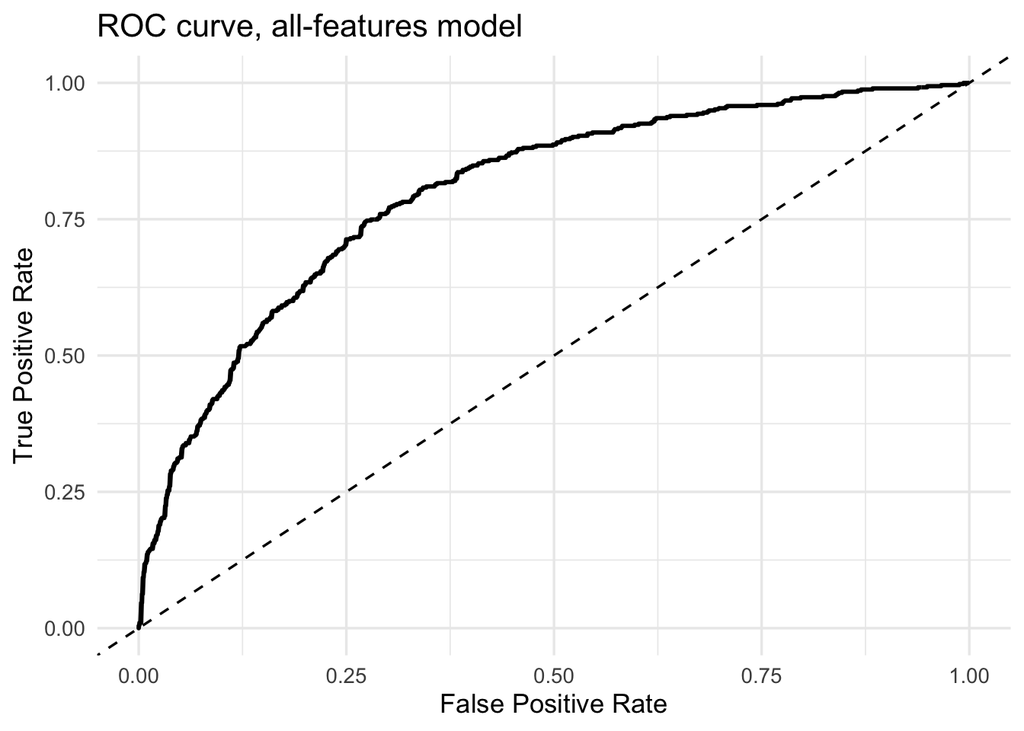

```r
roc_obj <- roc(response = test$click, predictor = test$p_hat, quiet = TRUE)
ggplot(data.frame(FPR = 1 - roc_obj$specificities,
                  TPR = roc_obj$sensitivities), aes(FPR, TPR)) +
  geom_line(linewidth = 1) +
  geom_abline(slope = 1, intercept = 0, linetype = "dashed") +
  labs(title = "ROC curve, all-features model",
       x = "False Positive Rate", y = "True Positive Rate") +
  theme_minimal(base_size = 13)
```

```r
round(as.numeric(auc(roc_obj)), 3)
```

```
## [1] 0.799
```

**Why is the diagonal a “random guess” baseline?**

A classifier that ranks impressions at random catches true positives at the same rate it triggers false positives, so its curve is the 45-degree line. A curve hugging the diagonal means the model barely separates clickers from non-clickers.

**What is the maximum possible AUC?**

Max is **1.0** (every clicker ranked above every non-clicker). Our **0.80** means: pick a random clicker and a random non-clicker, and the model scores the clicker higher 80% of the time.

# Task 6: Odds ratios, drawn

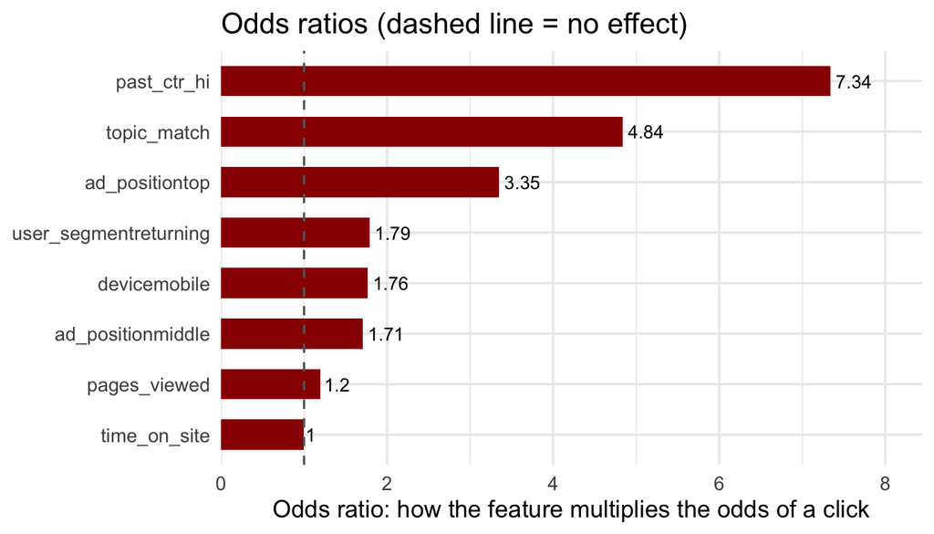

```r
or <- exp(coef(logit_full))
or <- or[names(or) != "(Intercept)"]
or_dt <- data.table(feature = names(or), odds_ratio = as.numeric(or))[order(odds_ratio)]
or_dt[, feature := factor(feature, levels = feature)]
ggplot(or_dt, aes(x = odds_ratio, y = feature)) +
  geom_col(fill = "#990000", width = 0.6) +
  geom_vline(xintercept = 1, linetype = "dashed", color = "grey40") +
  geom_text(aes(label = round(odds_ratio, 2)), hjust = -0.15, size = 3.5) +
  scale_x_continuous(expand = expansion(mult = c(0, 0.15))) +
  labs(title = "Odds ratios (dashed line = no effect)",
       x = "Odds ratio: how the feature multiplies the odds of a click",
       y = NULL) +
  theme_minimal(base_size = 13)
```

# Task 7: Pick a threshold for the business goal

The goal: at least **75% precision**, at the **lowest** threshold that clears it, so recall stays as high as possible.

```r
grid <- seq(0.05, 0.95, by = 0.01)
res <- rbindlist(lapply(grid, function(t) {
  pred <- as.integer(test$p_hat >= t)
  tp <- sum(pred == 1 & test$click == 1)
  fp <- sum(pred == 1 & test$click == 0)
  fn <- sum(pred == 0 & test$click == 1)
  tn <- sum(pred == 0 & test$click == 0)
  data.table(threshold = t, flagged = tp + fp,
             precision = ifelse(tp + fp > 0, tp / (tp + fp), NA),
             recall = tp / (tp + fn),
             accuracy = (tp + tn) / length(pred))
}))

# The lowest threshold clearing the 75% precision bar
best <- res[precision >= 0.75][which.min(threshold)]
best[, lapply(.SD, round, 3)]
```

```
##    threshold flagged precision recall accuracy
##        <num>   <num>     <num>  <num>    <num>
## 1:      0.63     220     0.755  0.335    0.745
```

```r
# The trade-off around it, and at the default cutoff
res[threshold %in% c(0.50, 0.55, 0.60, best$threshold, 0.70, 0.80),
    lapply(.SD, round, 3)]
```

```
##    threshold flagged precision recall accuracy
##        <num>   <num>     <num>  <num>    <num>
## 1:      0.50     351     0.672  0.477    0.751
## 2:      0.55     291     0.698  0.410    0.747
## 3:      0.63     220     0.755  0.335    0.745
## 4:      0.80      92     0.815  0.152    0.709
```

**The answer.** The lowest threshold that clears 75% precision is about **0.63**: precision **75.5%**, recall **33.5%**, flagging 220 of the 1,500 test impressions. Compared with the 0.5 cutoff we buy about **8 points of precision** and pay about **14 points of recall**.

**Does accuracy move as much?**

No: accuracy goes from **75.1% to 74.5%**, essentially flat through a trade-off that completely changes what the ad team would do. With a 33% click rate, accuracy is propped up by the easy “no click” majority (always predicting no-click already scores 67%), which is why the business goal is stated in precision and recall, not accuracy.

# If you finish early

## The best pair of features

```r
feats <- c("device", "ad_position", "user_segment", "pages_viewed",
           "time_on_site", "topic_match", "past_ctr_hi")
pairs <- combn(feats, 2, simplify = FALSE)
pair_auc <- rbindlist(lapply(pairs, function(p) {
  m <- glm(reformulate(p, "click"), data = train, family = binomial())
  pr <- predict(m, newdata = test, type = "response")
  data.table(pair = paste(p, collapse = " + "),
             test_auc = round(as.numeric(auc(roc(test$click, pr, quiet = TRUE))), 3))
}))
pair_auc[order(-test_auc)]
```

```
##                            pair test_auc
##                          <char>    <num>
##  1:   topic_match + past_ctr_hi    0.756
##  2:   ad_position + past_ctr_hi    0.726
##  3:        device + past_ctr_hi    0.711
##  4:  pages_viewed + past_ctr_hi    0.705
##  5:  user_segment + past_ctr_hi    0.698
##  6:  time_on_site + past_ctr_hi    0.676
##  7:   ad_position + topic_match    0.675
##  8:        device + topic_match    0.665
##  9:  pages_viewed + topic_match    0.661
## 10:  user_segment + topic_match    0.659
## 11:  time_on_site + topic_match    0.647
## 12:        device + ad_position    0.599
## 13:  ad_position + pages_viewed    0.598
## 14:  ad_position + user_segment    0.591
## 15:  ad_position + time_on_site    0.584
## 16:       device + pages_viewed    0.576
## 17:       device + user_segment    0.570
## 18: user_segment + pages_viewed    0.568
## 19:       device + time_on_site    0.563
## 20: pages_viewed + time_on_site    0.548
## 21: user_segment + time_on_site    0.543
##                            pair test_auc
##                          <char>    <num>
```

## A different business goal

```r
# Say the bar is 60% precision instead
res[precision >= 0.60][which.min(threshold)][, lapply(.SD, round, 3)]
```

```
##    threshold flagged precision recall accuracy
##        <num>   <num>     <num>  <num>    <num>
## 1:       0.4     511     0.609  0.628    0.744
```

A 60% bar is already cleared near the default cutoff, with much higher recall: the stricter the precision requirement, the more clickers you give up.

```r
# Or the budget only allows targeting the top 20% of impressions
cutoff20 <- quantile(test$p_hat, 0.80)
flagged  <- test[p_hat >= cutoff20]
data.table(cutoff    = round(cutoff20, 3),
           flagged   = nrow(flagged),
           precision = round(mean(flagged$click), 3),
           recall    = round(sum(flagged$click) / sum(test$click), 3))
```

```
##    cutoff flagged precision recall
##     <num>   <int>     <num>  <num>
## 1:   0.54     300     0.693   0.42
```

A top-20% budget flags **300 of the 1,500** test impressions, which lands the cutoff at about **0.54**: between the default 0.5 and the 0.63 that the 75% precision goal required. Precision comes out near **69%** and recall near **42%**. Note what happened: the budget picked the threshold for us, and that threshold misses the 75% bar. If the ad team insists on both the budget and the precision goal, something has to give.

## How much money does the model save?

```r
# An impression costs 1 cent; a click is worth 50 cents
everyone <- test[, .(impressions = .N, clicks = sum(click))]
targeted <- test[p_hat >= best$threshold, .(impressions = .N, clicks = sum(click))]
money <- rbind(cbind(policy = "show everyone", everyone),
               cbind(policy = "show above threshold", targeted))
money[, cost := impressions * 1]
money[, revenue := clicks * 50]
money[, profit := revenue - cost]
money[, profit_per_impression := round(profit / impressions, 2)]
money[]
```

```
##                  policy impressions clicks  cost revenue profit
##                  <char>       <int>  <int> <num>   <num>  <num>
## 1:        show everyone        1500    495  1500   24750  23250
## 2: show above threshold         220    166   220    8300   8080
##    profit_per_impression
##                    <num>
## 1:                 15.50
## 2:                 36.73
```

With these numbers, showing the ad to **everyone** earns more in total (clicks are worth 50 times an impression, and a third of impressions click), but the targeted policy earns far more **per impression**. The managerial answer: if impressions are unlimited and this cheap, show everyone; under a limited budget, spend it above the threshold first. A good group notices that the right policy depends on the economics, not just the model.